# Law of Large Numbers

Patrick Dolinger

01/03/2020

## Definition per Probability Theory

*In probability theory, the law of large numbers (LLN) is a theorem that describes the result of performing the same experiment a large number of times. According to the law, the average of the results obtained from a large number of trials should be close to the expected value, and will tend to become closer as more trials are performed.*

##### [Wikipedia](https://en.wikipedia.org/wiki/Law_of_large_numbers)

### Create Variables for Observations

- N represents the total number of observations, or in this example, coin flips.
- o represents the number of observations to display to look at the results as they are run.
- o should not exceed 100 for practical purposes.

*Comment out set.seed() to achieve randomness on subsequent runs*

```r
N <- 10000
o <- 10
set.seed(1963)  # added for the example - comment out for tests
```

### Create Variables for Iterations

Now we will set 3 variables to simulate the coin flips.

- x - stores the sample flips as a 0 or 1. The number of flips will me set by the value of N set previously.
- s - stores a running total of the occurrences of a value of “1”.
- r.avg - stores the running avg with each flip.

```r
x <- sample(0:1, N, replace = T)
s <- cumsum(x)
r.avg <- s/(1:N)
```

### Store the Means

Assign the running statistics gathered to the r.stats variable. Show the results (should limit to approx 100 observations in this list)

```r
r.stats <- round(cbind(x,s,r.avg), 3)[1:o,]
print(r.stats)
```

```
      x s r.avg
 [1,] 1 1 1.000
 [2,] 0 1 0.500
 [3,] 0 1 0.333
 [4,] 1 2 0.500
 [5,] 0 2 0.400
 [6,] 1 3 0.500
 [7,] 0 3 0.429
 [8,] 1 4 0.500
 [9,] 1 5 0.556
[10,] 0 5 0.500
```

### Graph the Results

Create a plot chart to illustrate how the means of the sample approximately equals the population with large sample sizes. *scipen used to influence the x axis to use whole numbers for large observation counts*

The plot uses line charts to reflect (1) the running averages of the coin flips and (2) the expected average of the population (.5).

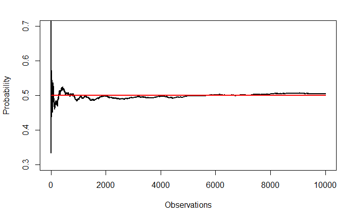

```r
options(scipen = 10)
plot(r.avg, ylim=c(.30, .70), type = "l", xlab = "Observations"
     ,ylab = "Probability", lwd = 2)
lines(c(0,N), c(.50,.50),col="red", lwd = 2)
```